# Changes on CRAN

2025-10-01 to 2025-12-31

“Changes on CRAN” published in The R Journal.

Kurt Hornik (WU Wirtschaftsuniversität Wien) , Uwe Ligges (TU Dortmund) , Achim Zeileis (Universität Innsbruck)  
2025-12-01

## 1 CRAN growth

In the past 3 months, 590 new packages were added to the CRAN package repository. 158 packages were unarchived, 594 were archived and 0 had to be removed. The following shows the growth of the number of active packages in the CRAN package repository:

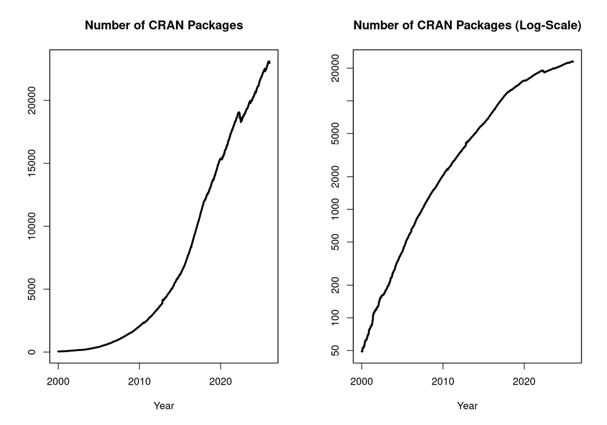

On 2025-12-31, the number of active packages was around 22969.

## 2 CRAN package submissions

From October 2025 to December 2025 CRAN received 7066 package submissions. For these, 11187 actions took place of which 8337 (75%) were auto processed actions and 2850 (25%) manual actions.

Minus some special cases, a summary of the auto-processed and manually triggered actions follows:

|  | archive | inspect | newbies | pending | pretest | publish | recheck | waiting |
| --- | --- | --- | --- | --- | --- | --- | --- | --- |
| auto | 2258 | 634 | 1643 | 146 | 0 | 2306 | 770 | 308 |
| manual | 1072 | 1 | 7 | 7 | 87 | 1345 | 244 | 83 |

These include the final decisions for the submissions which were

|  | archive | publish |
| --- | --- | --- |
| auto | 2132 (31.2%) | 2099 (30.7%) |
| manual | 1066 (15.6%) | 1545 (22.6%) |

where we only count those as *auto* processed whose publication or rejection happened automatically in all steps.

## 3 CRAN mirror security

Currently, there are 93 official CRAN mirrors, 77 of which provide both secure downloads via ‘`https`’ *and* use secure mirroring from the CRAN master (via rsync through ssh tunnels). Since the R 3.4.0 release, `chooseCRANmirror()` offers these mirrors in preference to the others which are not fully secured (yet).

## 4 CRAN Task View Initiative

Currently, there are 49 task views (see https://CRAN.R-project.org/web/views/), with median and mean numbers of CRAN packages covered 110 and 123, respectively. Overall, these task views cover 5003 CRAN packages, which is about 22% of all active CRAN packages.